# Modeling and prediction for movies

## Setup

### Load packages

```r
library(ggplot2)
library(dplyr)
library(statsr)
library(grid)
library(gridExtra)
```

### Load data

```r
load("movies.Rdata")
```

## Part 1: Data

The data set is comprised of 651 randomly sampled movies produced and released before 2016. It includes information from Rotten Tomatoes and IMDB for a random sample of movies. Each row (651 rows in total) corresponds to some specific movie, whereas 32 columns hold information about various features of movies such as title, genre, runtime etc.

### Generabizability

As random sampling strategy is deployed in this study, the results can be generalized to the all movies produced and released before 2016. However, there is voluntary response bias in variables related to the ranking of the movies due to the fact that rankings are compiled based on responses of users registered on IMDB and Rotten Tomatoes and voted for those movies.

### Causality

Due to observational nature of the study no causal relationship could be made from data.

## Part 2: Research question

The objective of the study is to learn what attributes make a movie popular and make a prediction on popularity of the movies based on constructed model.

Based on available data, IMDB ranking should be a reasonable indicator of popularity of the movie. Therefore IMDB rating will be chosen as a response variable. Whereas, there could be a lot of variables affecting the popularity of the movie, based on available data and subjective opinion following variables are chosen to be explanatary variables that are going to be used to predict the movie popularity:

- genre (genre of the movie)
- runtime (runtime of the movie),
- imdb_num_votes (Number of votes on IMDB),
- critics_score (score given by critics),
- audience_score (audience score on Rotten Tomatoes),
- best_pic_nom (Whether or not the movie was nominated for a best picture (Oscar) (no, yes)),
- best_pic_win (Whether or not the movie won a best picture (Oscar) (no, yes)),
- best_actor_win (Whether or not one of the main actors in the movie ever won an Oscar (no, yes)),
- best_actress win (Whether or not one of the main actresses in the movie ever won an Oscar (no, yes)),
- best_dir_win (Whether or not the director of the movie ever won an Oscar (no, yes) ),
- top200_box (Whether or not the movie is in the Top 200 Box Office list on BoxOfficeMojo (no, yes))

## Part 3: Exploratory data analysis

A good step before we start EDA and modelling is to subset data to include only the required variables, remove the observations with missing data (NA values) and present summary of the dataframe.

```r
movies_subset <- movies %>% select (imdb_rating, genre,runtime, studio, imdb_num_votes, critics_score, audience_score, best_pic_nom, best_pic_win, best_actor_win, best_actress_win, best_dir_win, top200_box)

movies_subset <- na.omit(movies_subset)
summary(movies_subset)
```

```
##   imdb_rating                 genre        runtime
##  Min.   :1.9   Drama             :303   Min.   : 39
##  1st Qu.:5.9   Comedy            : 86   1st Qu.: 93
##  Median :6.6   Action & Adventure: 64   Median :103
##  Mean   :6.5   Mystery & Suspense: 59   Mean   :106
##  3rd Qu.:7.3   Documentary       : 51   3rd Qu.:116
##  Max.   :9.0   Horror            : 22   Max.   :267
##                (Other)           : 57
##                               studio    imdb_num_votes   critics_score
##  Paramount Pictures              : 37   Min.   :   180   Min.   :  1.00
##  Warner Bros. Pictures           : 30   1st Qu.:  4861   1st Qu.: 33.00
##  Sony Pictures Home Entertainment: 27   Median : 15470   Median : 61.00
##  Universal Pictures              : 23   Mean   : 58255   Mean   : 57.78
##  Warner Home Video               : 19   3rd Qu.: 59034   3rd Qu.: 83.00
##  20th Century Fox                : 18   Max.   :893008   Max.   :100.00
##  (Other)                         :488
##  audience_score best_pic_nom best_pic_win best_actor_win best_actress_win
##  Min.   :11.0   no :620      no :635      no :550        no :570
##  1st Qu.:46.0   yes: 22      yes:  7      yes: 92        yes: 72
##  Median :65.0
##  Mean   :62.5
##  3rd Qu.:80.0
##  Max.   :97.0
##
##  best_dir_win top200_box
##  no :599      no :627
##  yes: 43      yes: 15
##
##
##
##
##
```

It is useful to visualize the distribution of values of response variable and presents its summary statistics.

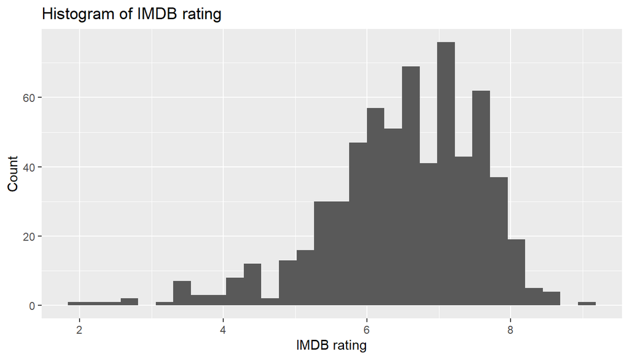

```r
ggplot(movies_subset, aes(x = imdb_rating)) + geom_histogram() + xlab("IMDB rating") + ylab("Count") + ggtitle("Histogram of IMDB rating")
```

```r
summary(movies_subset$imdb_rating)
```

```
##    Min. 1st Qu.  Median    Mean 3rd Qu.    Max.
##     1.9     5.9     6.6     6.5     7.3     9.0
```

According to histogram, the distribution of IMDB ratings is slightly left skewed with mean of 6.5. The sample dataset has quite large range of values between 1.9 and 9.0.

Next, we will look at the distribution of numerical explanatory variables.

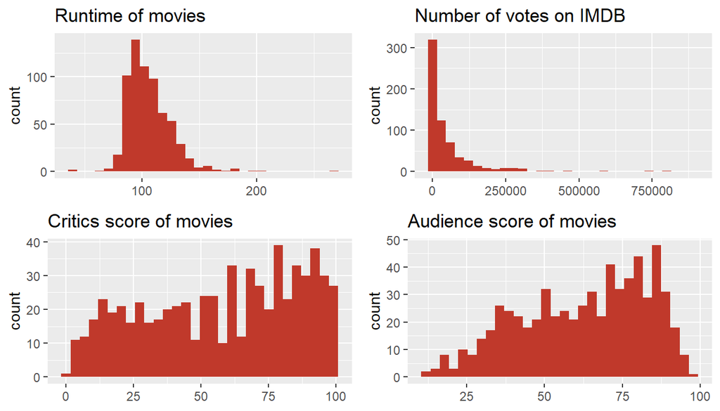

```r
p1<-ggplot(data=movies , aes(x=runtime)) + geom_histogram(fill ="#c0392b") + ggtitle("Runtime of movies") + theme(axis.title.x=element_blank())
p2<-ggplot(data=movies_subset , aes(x=imdb_num_votes)) + geom_histogram(fill ="#c0392b") + ggtitle("Number of votes on IMDB") + theme(axis.title.x=element_blank())
p3<-ggplot(data=movies , aes(x=critics_score)) + geom_histogram(fill ="#c0392b") + ggtitle("Critics score of movies") + theme(axis.title.x=element_blank())
p4<-ggplot(data=movies_subset , aes(x=audience_score)) + geom_histogram(fill ="#c0392b") + ggtitle("Audience score of movies") + theme(axis.title.x=element_blank())
grid.arrange(p1, p2, p3, p4, nrow=2)
```

Based on 4 histograms shown above, we may observe the following:

1. Runtime of the movies is approximately normally distributed with a mean value of around 100 minutes
2. Number of votes on IMDB for movies is strongly right skewed (most movies got less than 250 000 votes)
3. The distribution of scores given by critics is approximately uniform
4. The distribution of scores given by audience is left skewed with mean around 62

Now we can observe the distribution of categorical variables

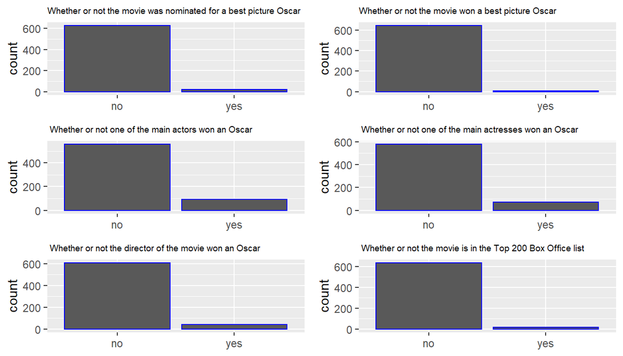

```r
p5<-ggplot(data=movies , aes(x=best_pic_nom )) + geom_bar(color = "blue") + ggtitle("Whether or not the movie was nominated for a best picture Oscar") +
theme(axis.title.x=element_blank(), plot.title = element_text(size=7))
p6<-ggplot(data=movies , aes(x=best_pic_win )) + geom_bar(color = "blue") + ggtitle("Whether or not the movie won a best picture Oscar") +
theme(axis.title.x=element_blank(), plot.title = element_text(size=7))
p7<-ggplot(data=movies , aes(x=best_actor_win )) + geom_bar(color = "blue") + ggtitle(" Whether or not one of the main actors won an Oscar ") +
theme(axis.title.x=element_blank(), plot.title = element_text(size=7))
p8<-ggplot(data=movies , aes(x=best_actress_win )) + geom_bar(color = "blue") + ggtitle(" Whether or not one of the main actresses won an Oscar ") +
theme(axis.title.x=element_blank(), plot.title = element_text(size=7))
p9<-ggplot(data=movies , aes(x=best_dir_win )) + geom_bar(color = "blue") + ggtitle(" Whether or not the director of the movie won an Oscar ") +
theme(axis.title.x=element_blank(), plot.title = element_text(size=7))
p10<-ggplot(data=movies , aes(x=top200_box)) + geom_bar(color = "blue") + ggtitle(" Whether or not the movie is in the Top 200 Box Office list ") +
theme(axis.title.x=element_blank(), plot.title = element_text(size=7))
grid.arrange(p5, p6, p7, p8, p9, p10 ,nrow=3)
```

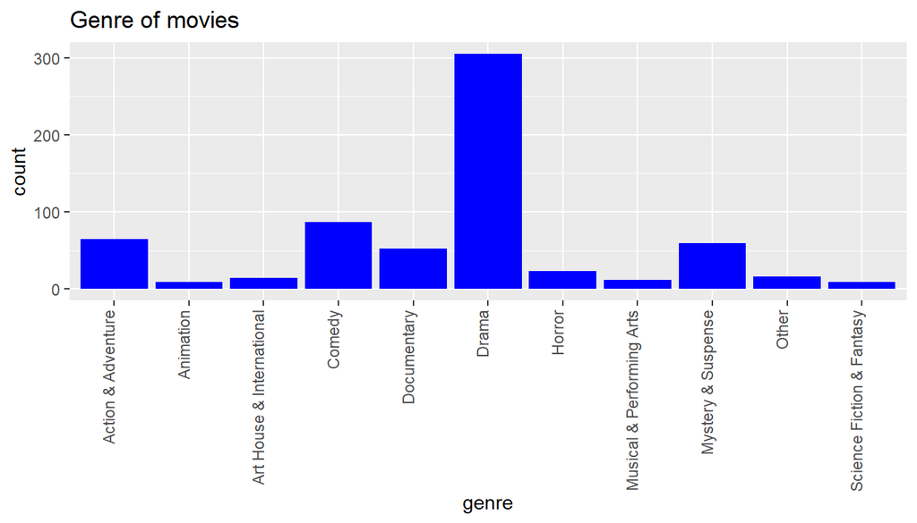

```r
ggplot(data=movies, aes(x=genre)) + geom_bar(fill="blue") + ggtitle("Genre of movies") + theme(axis.text.x=element_text(angle=90, hjust=1, vjust=0))
```

Based on 7 bar charts shown above, we may observe the following: * Most of the movies in sample have not nominated or received best picture Oscar * Main actor and actresses and directors of the movies have not ever won an Oscar * Very small number of the movies was included in Top 200 box office list * Large fraction of the movies in our samples fall into Drama genre

## Part 4: Modeling

```r
movies_model1 = lm(imdb_rating ~ genre + runtime+ imdb_num_votes + critics_score + audience_score + best_pic_nom+best_pic_win+ best_actor_win + best_actress_win + best_dir_win + top200_box , data = movies)
summary(movies_model1)
```

```
##
## Call:
## lm(formula = imdb_rating ~ genre + runtime + imdb_num_votes +
##     critics_score + audience_score + best_pic_nom + best_pic_win +
##     best_actor_win + best_actress_win + best_dir_win + top200_box,
##     data = movies)
##
## Residuals:
##      Min       1Q   Median       3Q      Max
## -2.40417 -0.18034  0.02843  0.25914  1.11834
##
## Coefficients:
##                                  Estimate Std. Error t value Pr(>|t|)
## (Intercept)                     3.342e+00  1.338e-01  24.978  < 2e-16 ***
## genreAnimation                 -3.751e-01  1.654e-01  -2.268 0.023692 *
## genreArt House & International  2.691e-01  1.375e-01   1.958 0.050722 .
## genreComedy                    -1.334e-01  7.660e-02  -1.742 0.082020 .
## genreDocumentary                3.563e-01  9.686e-02   3.678 0.000255 ***
## genreDrama                      8.793e-02  6.664e-02   1.320 0.187451
## genreHorror                     1.083e-01  1.132e-01   0.957 0.338841
## genreMusical & Performing Arts  1.103e-01  1.495e-01   0.737 0.461153
## genreMystery & Suspense         2.527e-01  8.486e-02   2.978 0.003011 **
## genreOther                     -6.761e-02  1.303e-01  -0.519 0.603883
## genreScience Fiction & Fantasy -1.977e-01  1.641e-01  -1.204 0.228950
## runtime                         3.707e-03  1.108e-03   3.346 0.000870 ***
## imdb_num_votes                  9.098e-07  1.986e-07   4.580 5.59e-06 ***
## critics_score                   1.028e-02  9.342e-04  11.002  < 2e-16 ***
## audience_score                  3.253e-02  1.354e-03  24.033  < 2e-16 ***
## best_pic_nomyes                -8.772e-02  1.209e-01  -0.726 0.468187
## best_pic_winyes                -1.016e-01  2.128e-01  -0.477 0.633220
## best_actor_winyes               3.985e-02  5.465e-02   0.729 0.466171
## best_actress_winyes             5.680e-02  6.069e-02   0.936 0.349638
## best_dir_winyes                 5.032e-02  7.935e-02   0.634 0.526222
## top200_boxyes                  -1.429e-01  1.274e-01  -1.122 0.262363
## ---
## Signif. codes:  0 '***' 0.001 '**' 0.01 '*' 0.05 '.' 0.1 ' ' 1
##
## Residual standard error: 0.4599 on 629 degrees of freedom
##   (1 observation deleted due to missingness)
## Multiple R-squared:  0.8259, Adjusted R-squared:  0.8203
## F-statistic: 149.2 on 20 and 629 DF,  p-value: < 2.2e-16
```

Next step in backward elimination method based on p-value is to drop the variable with the highest p-value above 0.05 threshold that represents the rate of insignificancy the predictor. Therefore at this step we drop variable best_pic_win

```r
movies_model2 = lm(imdb_rating ~ genre + runtime+ imdb_num_votes + critics_score + audience_score + best_pic_nom + best_actor_win + best_actress_win + best_dir_win + top200_box , data = movies)
summary(movies_model2)
```

```
##
## Call:
## lm(formula = imdb_rating ~ genre + runtime + imdb_num_votes +
##     critics_score + audience_score + best_pic_nom + best_actor_win +
##     best_actress_win + best_dir_win + top200_box, data = movies)
##
## Residuals:
##      Min       1Q   Median       3Q      Max
## -2.40387 -0.18415  0.03234  0.25850  1.11901
##
## Coefficients:
##                                  Estimate Std. Error t value Pr(>|t|)
## (Intercept)                     3.342e+00  1.337e-01  24.996  < 2e-16 ***
## genreAnimation                 -3.763e-01  1.653e-01  -2.276 0.023162 *
## genreArt House & International  2.673e-01  1.373e-01   1.946 0.052042 .
## genreComedy                    -1.349e-01  7.650e-02  -1.763 0.078362 .
## genreDocumentary                3.538e-01  9.666e-02   3.660 0.000273 ***
## genreDrama                      8.727e-02  6.658e-02   1.311 0.190403
## genreHorror                     1.077e-01  1.131e-01   0.953 0.341191
## genreMusical & Performing Arts  1.089e-01  1.494e-01   0.729 0.466201
## genreMystery & Suspense         2.521e-01  8.480e-02   2.973 0.003059 **
## genreOther                     -6.434e-02  1.300e-01  -0.495 0.620820
## genreScience Fiction & Fantasy -1.967e-01  1.640e-01  -1.199 0.230869
## runtime                         3.705e-03  1.107e-03   3.346 0.000869 ***
## imdb_num_votes                  8.940e-07  1.957e-07   4.568 5.93e-06 ***
## critics_score                   1.027e-02  9.336e-04  11.006  < 2e-16 ***
## audience_score                  3.257e-02  1.351e-03  24.102  < 2e-16 ***
## best_pic_nomyes                -1.110e-01  1.105e-01  -1.004 0.315878
## best_actor_winyes               4.175e-02  5.447e-02   0.766 0.443669
## best_actress_winyes             5.544e-02  6.058e-02   0.915 0.360438
## best_dir_winyes                 3.979e-02  7.618e-02   0.522 0.601625
## top200_boxyes                  -1.432e-01  1.273e-01  -1.125 0.261180
## ---
## Signif. codes:  0 '***' 0.001 '**' 0.01 '*' 0.05 '.' 0.1 ' ' 1
##
## Residual standard error: 0.4596 on 630 degrees of freedom
##   (1 observation deleted due to missingness)
## Multiple R-squared:  0.8258, Adjusted R-squared:  0.8205
## F-statistic: 157.2 on 19 and 630 DF,  p-value: < 2.2e-16
```

Next we drop best_dir_win variable

```r
movies_model3 = lm(imdb_rating ~ genre + runtime+ imdb_num_votes + critics_score + audience_score + best_pic_nom + best_actor_win + best_actress_win + top200_box , data = movies)
summary(movies_model3)
```

```
##
## Call:
## lm(formula = imdb_rating ~ genre + runtime + imdb_num_votes +
##     critics_score + audience_score + best_pic_nom + best_actor_win +
##     best_actress_win + top200_box, data = movies)
##
## Residuals:
##      Min       1Q   Median       3Q      Max
## -2.40336 -0.18384  0.03605  0.25908  1.11713
##
## Coefficients:
##                                  Estimate Std. Error t value Pr(>|t|)
## (Intercept)                     3.333e+00  1.326e-01  25.145  < 2e-16 ***
## genreAnimation                 -3.775e-01  1.652e-01  -2.285 0.022623 *
## genreArt House & International  2.651e-01  1.372e-01   1.933 0.053727 .
## genreComedy                    -1.348e-01  7.645e-02  -1.763 0.078370 .
## genreDocumentary                3.508e-01  9.644e-02   3.638 0.000297 ***
## genreDrama                      8.637e-02  6.652e-02   1.298 0.194638
## genreHorror                     1.082e-01  1.130e-01   0.957 0.338772
## genreMusical & Performing Arts  1.079e-01  1.493e-01   0.723 0.470002
## genreMystery & Suspense         2.521e-01  8.475e-02   2.975 0.003045 **
## genreOther                     -6.673e-02  1.298e-01  -0.514 0.607472
## genreScience Fiction & Fantasy -1.948e-01  1.639e-01  -1.189 0.235072
## runtime                         3.797e-03  1.093e-03   3.476 0.000544 ***
## imdb_num_votes                  9.016e-07  1.951e-07   4.622 4.61e-06 ***
## critics_score                   1.032e-02  9.291e-04  11.107  < 2e-16 ***
## audience_score                  3.255e-02  1.350e-03  24.110  < 2e-16 ***
## best_pic_nomyes                -1.078e-01  1.103e-01  -0.977 0.328707
## best_actor_winyes               4.263e-02  5.441e-02   0.783 0.433631
## best_actress_winyes             5.590e-02  6.054e-02   0.923 0.356139
## top200_boxyes                  -1.452e-01  1.272e-01  -1.142 0.253961
## ---
## Signif. codes:  0 '***' 0.001 '**' 0.01 '*' 0.05 '.' 0.1 ' ' 1
##
## Residual standard error: 0.4593 on 631 degrees of freedom
##   (1 observation deleted due to missingness)
## Multiple R-squared:  0.8257, Adjusted R-squared:  0.8207
## F-statistic: 166.1 on 18 and 631 DF,  p-value: < 2.2e-16
```

Next we drop best_actor_win variable

```r
movies_model4 = lm(imdb_rating ~ genre + runtime+ imdb_num_votes + critics_score + audience_score + best_pic_nom  + best_actress_win + top200_box , data = movies)
summary(movies_model4)
```

```
##
## Call:
## lm(formula = imdb_rating ~ genre + runtime + imdb_num_votes +
##     critics_score + audience_score + best_pic_nom + best_actress_win +
##     top200_box, data = movies)
##
## Residuals:
##      Min       1Q   Median       3Q      Max
## -2.40492 -0.18367  0.03455  0.25968  1.11114
##
## Coefficients:
##                                  Estimate Std. Error t value Pr(>|t|)
## (Intercept)                     3.322e+00  1.317e-01  25.218  < 2e-16 ***
## genreAnimation                 -3.747e-01  1.651e-01  -2.269 0.023582 *
## genreArt House & International  2.605e-01  1.370e-01   1.901 0.057703 .
## genreComedy                    -1.348e-01  7.643e-02  -1.763 0.078334 .
## genreDocumentary                3.491e-01  9.639e-02   3.622 0.000316 ***
## genreDrama                      8.753e-02  6.648e-02   1.317 0.188434
## genreHorror                     1.052e-01  1.129e-01   0.931 0.352188
## genreMusical & Performing Arts  1.054e-01  1.492e-01   0.706 0.480264
## genreMystery & Suspense         2.574e-01  8.445e-02   3.047 0.002405 **
## genreOther                     -6.554e-02  1.298e-01  -0.505 0.613767
## genreScience Fiction & Fantasy -1.992e-01  1.637e-01  -1.216 0.224318
## runtime                         3.964e-03  1.071e-03   3.701 0.000234 ***
## imdb_num_votes                  8.944e-07  1.948e-07   4.591 5.31e-06 ***
## critics_score                   1.033e-02  9.287e-04  11.126  < 2e-16 ***
## audience_score                  3.252e-02  1.349e-03  24.105  < 2e-16 ***
## best_pic_nomyes                -9.908e-02  1.097e-01  -0.903 0.366866
## best_actress_winyes             5.839e-02  6.044e-02   0.966 0.334396
## top200_boxyes                  -1.423e-01  1.271e-01  -1.120 0.263344
## ---
## Signif. codes:  0 '***' 0.001 '**' 0.01 '*' 0.05 '.' 0.1 ' ' 1
##
## Residual standard error: 0.4592 on 632 degrees of freedom
##   (1 observation deleted due to missingness)
## Multiple R-squared:  0.8256, Adjusted R-squared:  0.8209
## F-statistic: 175.9 on 17 and 632 DF,  p-value: < 2.2e-16
```

Next we drop best_pic_nom variable

```r
movies_model5 = lm(imdb_rating ~ genre + runtime+ imdb_num_votes + critics_score + audience_score  + best_actress_win + top200_box , data = movies)
summary(movies_model5)
```

```
##
## Call:
## lm(formula = imdb_rating ~ genre + runtime + imdb_num_votes +
##     critics_score + audience_score + best_actress_win + top200_box,
##     data = movies)
##
## Residuals:
##      Min       1Q   Median       3Q      Max
## -2.41016 -0.19001  0.03461  0.26174  1.11402
##
## Coefficients:
##                                  Estimate Std. Error t value Pr(>|t|)
## (Intercept)                     3.343e+00  1.296e-01  25.789  < 2e-16 ***
## genreAnimation                 -3.754e-01  1.651e-01  -2.274 0.023298 *
## genreArt House & International  2.597e-01  1.370e-01   1.896 0.058407 .
## genreComedy                    -1.371e-01  7.637e-02  -1.795 0.073051 .
## genreDocumentary                3.500e-01  9.637e-02   3.632 0.000304 ***
## genreDrama                      8.542e-02  6.643e-02   1.286 0.198988
## genreHorror                     1.016e-01  1.129e-01   0.900 0.368418
## genreMusical & Performing Arts  1.084e-01  1.492e-01   0.727 0.467781
## genreMystery & Suspense         2.571e-01  8.444e-02   3.045 0.002427 **
## genreOther                     -7.247e-02  1.295e-01  -0.559 0.576040
## genreScience Fiction & Fantasy -1.992e-01  1.637e-01  -1.217 0.224153
## runtime                         3.843e-03  1.063e-03   3.617 0.000322 ***
## imdb_num_votes                  8.582e-07  1.906e-07   4.503 7.99e-06 ***
## critics_score                   1.029e-02  9.272e-04  11.095  < 2e-16 ***
## audience_score                  3.245e-02  1.347e-03  24.098  < 2e-16 ***
## best_actress_winyes             5.057e-02  5.981e-02   0.845 0.398153
## top200_boxyes                  -1.395e-01  1.270e-01  -1.098 0.272720
## ---
## Signif. codes:  0 '***' 0.001 '**' 0.01 '*' 0.05 '.' 0.1 ' ' 1
##
## Residual standard error: 0.4591 on 633 degrees of freedom
##   (1 observation deleted due to missingness)
## Multiple R-squared:  0.8253, Adjusted R-squared:  0.8209
## F-statistic: 186.9 on 16 and 633 DF,  p-value: < 2.2e-16
```

Next we drop best_actress_win variable

```r
movies_model6 = lm(imdb_rating ~ genre + runtime+ imdb_num_votes + critics_score + audience_score  + top200_box , data = movies)
summary(movies_model6)
```

```
##
## Call:
## lm(formula = imdb_rating ~ genre + runtime + imdb_num_votes +
##     critics_score + audience_score + top200_box, data = movies)
##
## Residuals:
##      Min       1Q   Median       3Q      Max
## -2.40750 -0.19018  0.03386  0.26106  1.10635
##
## Coefficients:
##                                  Estimate Std. Error t value Pr(>|t|)
## (Intercept)                     3.330e+00  1.286e-01  25.884  < 2e-16 ***
## genreAnimation                 -3.667e-01  1.647e-01  -2.227 0.026329 *
## genreArt House & International  2.648e-01  1.368e-01   1.935 0.053441 .
## genreComedy                    -1.304e-01  7.594e-02  -1.717 0.086444 .
## genreDocumentary                3.532e-01  9.628e-02   3.668 0.000265 ***
## genreDrama                      9.287e-02  6.583e-02   1.411 0.158786
## genreHorror                     1.035e-01  1.128e-01   0.917 0.359358
## genreMusical & Performing Arts  1.082e-01  1.491e-01   0.726 0.468389
## genreMystery & Suspense         2.648e-01  8.392e-02   3.156 0.001676 **
## genreOther                     -6.740e-02  1.294e-01  -0.521 0.602579
## genreScience Fiction & Fantasy -1.995e-01  1.637e-01  -1.219 0.223400
## runtime                         3.976e-03  1.051e-03   3.785 0.000168 ***
## imdb_num_votes                  8.655e-07  1.904e-07   4.547 6.53e-06 ***
## critics_score                   1.032e-02  9.263e-04  11.139  < 2e-16 ***
## audience_score                  3.240e-02  1.345e-03  24.090  < 2e-16 ***
## top200_boxyes                  -1.337e-01  1.268e-01  -1.054 0.292320
## ---
## Signif. codes:  0 '***' 0.001 '**' 0.01 '*' 0.05 '.' 0.1 ' ' 1
##
## Residual standard error: 0.459 on 634 degrees of freedom
##   (1 observation deleted due to missingness)
## Multiple R-squared:  0.8251, Adjusted R-squared:  0.821
## F-statistic: 199.4 on 15 and 634 DF,  p-value: < 2.2e-16
```

Next we drop top200_box variable

```r
movies_model7 = lm(imdb_rating ~ genre + runtime+ imdb_num_votes + critics_score + audience_score , data = movies)
summary(movies_model7)
```

```
##
## Call:
## lm(formula = imdb_rating ~ genre + runtime + imdb_num_votes +
##     critics_score + audience_score, data = movies)
##
## Residuals:
##      Min       1Q   Median       3Q      Max
## -2.39955 -0.19572  0.03305  0.25980  1.10929
##
## Coefficients:
##                                  Estimate Std. Error t value Pr(>|t|)
## (Intercept)                     3.329e+00  1.286e-01  25.879  < 2e-16 ***
## genreAnimation                 -3.579e-01  1.645e-01  -2.176 0.029949 *
## genreArt House & International  2.722e-01  1.367e-01   1.992 0.046844 *
## genreComedy                    -1.236e-01  7.567e-02  -1.633 0.102956
## genreDocumentary                3.618e-01  9.593e-02   3.772 0.000177 ***
## genreDrama                      1.011e-01  6.537e-02   1.546 0.122528
## genreHorror                     1.111e-01  1.126e-01   0.987 0.324070
## genreMusical & Performing Arts  1.181e-01  1.489e-01   0.793 0.427953
## genreMystery & Suspense         2.740e-01  8.348e-02   3.282 0.001087 **
## genreOther                     -6.208e-02  1.293e-01  -0.480 0.631274
## genreScience Fiction & Fantasy -2.034e-01  1.637e-01  -1.243 0.214467
## runtime                         3.928e-03  1.050e-03   3.742 0.000199 ***
## imdb_num_votes                  8.203e-07  1.855e-07   4.422 1.15e-05 ***
## critics_score                   1.026e-02  9.248e-04  11.095  < 2e-16 ***
## audience_score                  3.241e-02  1.345e-03  24.103  < 2e-16 ***
## ---
## Signif. codes:  0 '***' 0.001 '**' 0.01 '*' 0.05 '.' 0.1 ' ' 1
##
## Residual standard error: 0.459 on 635 degrees of freedom
##   (1 observation deleted due to missingness)
## Multiple R-squared:  0.8248, Adjusted R-squared:  0.821
## F-statistic: 213.6 on 14 and 635 DF,  p-value: < 2.2e-16
```

Finally we end up with model, where we do not have any insignificant predictors. Moreover, while we we got very minor improvement in the value of adjusted R-squared (from 0.8203 in initial model to 0.821 in final model) we significantly simplified the model and left with the variables that contribute to the popularity of the movie.

### Model diagnostics

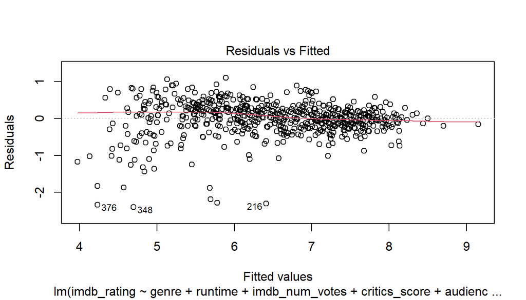

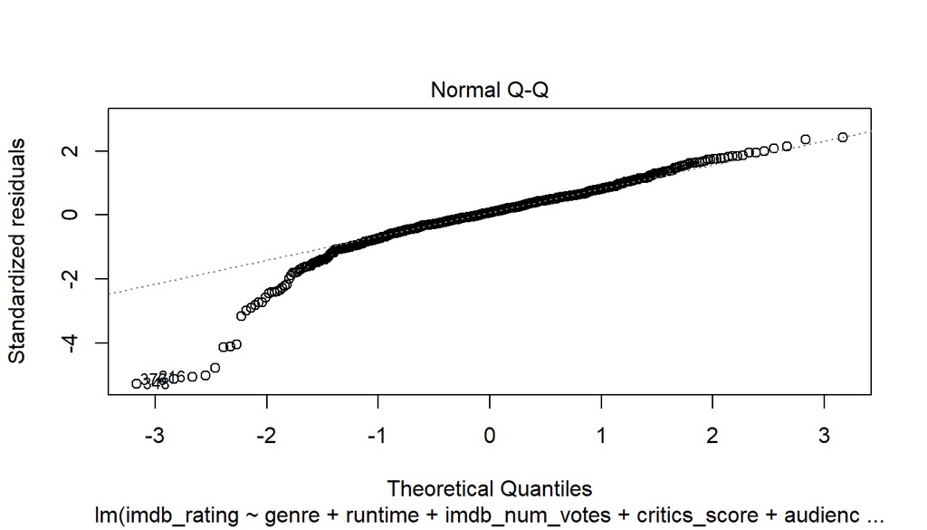

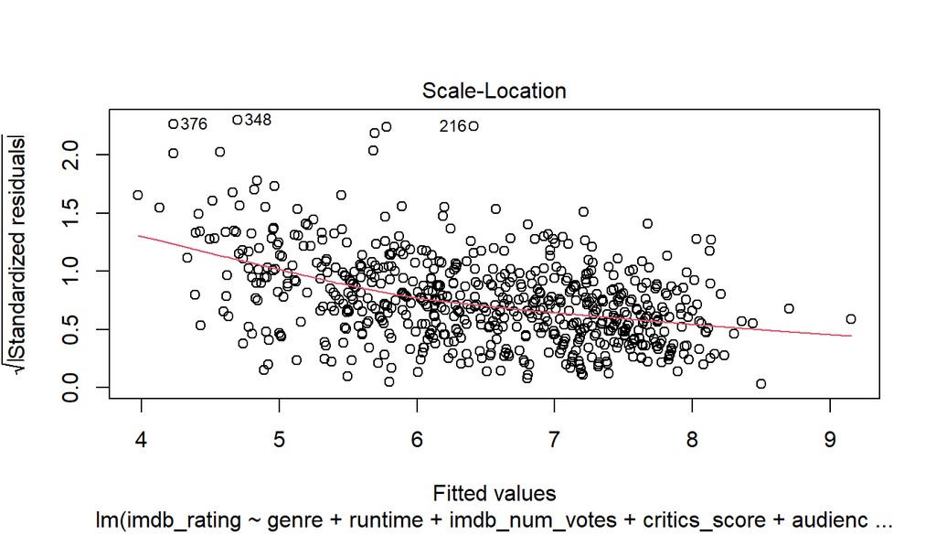

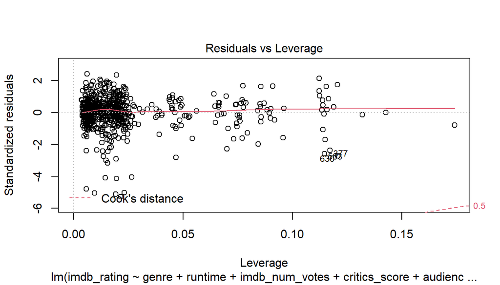

```r
plot(movies_model7)
```

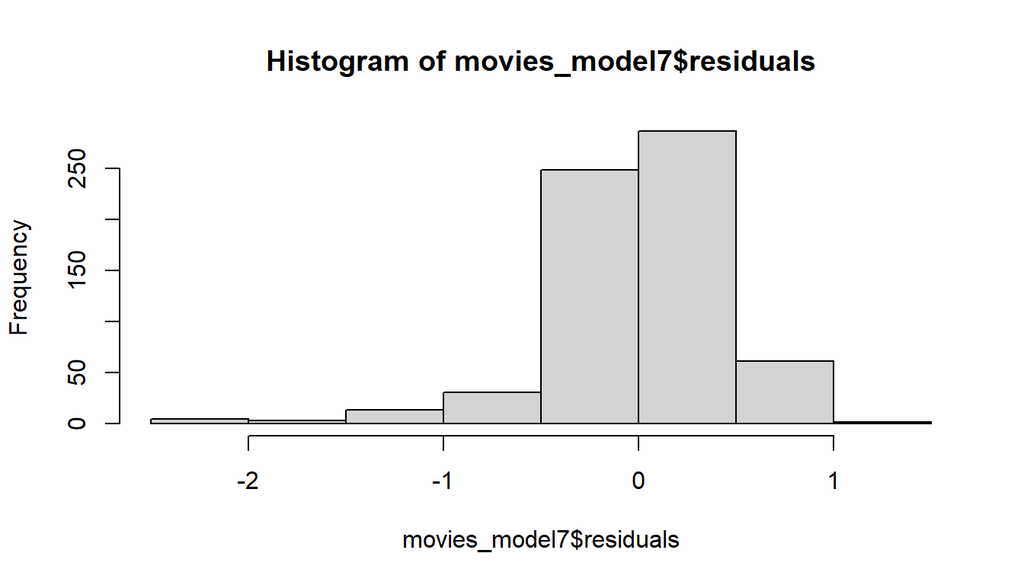

```r
hist(movies_model7$residuals)
```

### Interpretation of model coefficients

```r
summary(movies_model7)
```

```
##
## Call:
## lm(formula = imdb_rating ~ genre + runtime + imdb_num_votes +
##     critics_score + audience_score, data = movies)
##
## Residuals:
##      Min       1Q   Median       3Q      Max
## -2.39955 -0.19572  0.03305  0.25980  1.10929
##
## Coefficients:
##                                  Estimate Std. Error t value Pr(>|t|)
## (Intercept)                     3.329e+00  1.286e-01  25.879  < 2e-16 ***
## genreAnimation                 -3.579e-01  1.645e-01  -2.176 0.029949 *
## genreArt House & International  2.722e-01  1.367e-01   1.992 0.046844 *
## genreComedy                    -1.236e-01  7.567e-02  -1.633 0.102956
## genreDocumentary                3.618e-01  9.593e-02   3.772 0.000177 ***
## genreDrama                      1.011e-01  6.537e-02   1.546 0.122528
## genreHorror                     1.111e-01  1.126e-01   0.987 0.324070
## genreMusical & Performing Arts  1.181e-01  1.489e-01   0.793 0.427953
## genreMystery & Suspense         2.740e-01  8.348e-02   3.282 0.001087 **
## genreOther                     -6.208e-02  1.293e-01  -0.480 0.631274
## genreScience Fiction & Fantasy -2.034e-01  1.637e-01  -1.243 0.214467
## runtime                         3.928e-03  1.050e-03   3.742 0.000199 ***
## imdb_num_votes                  8.203e-07  1.855e-07   4.422 1.15e-05 ***
## critics_score                   1.026e-02  9.248e-04  11.095  < 2e-16 ***
## audience_score                  3.241e-02  1.345e-03  24.103  < 2e-16 ***
## ---
## Signif. codes:  0 '***' 0.001 '**' 0.01 '*' 0.05 '.' 0.1 ' ' 1
##
## Residual standard error: 0.459 on 635 degrees of freedom
##   (1 observation deleted due to missingness)
## Multiple R-squared:  0.8248, Adjusted R-squared:  0.821
## F-statistic: 213.6 on 14 and 635 DF,  p-value: < 2.2e-16
```

In the final model we are left with 5 variables, namely genre, runtime, imdb_num_votes, critics_score, audience_score.

## Part 5: Prediction

Here we will use our model to predict the IMDB rating of the movie “Up”, which was released in 2009. First we should get the data to input for our predictor variables (genre, runtime, imdb_num_votes, critics_score, audience_score). The data for the 1st 3 variables can be accessed from https://www.imdb.com/title/tt1049413/, while for the latter 2 variables from https://www.rottentomatoes.com/m/up/.

We create a new dataframe to hold the data for the new movie:

```r
data_up <- data.frame(genre="Action & Adventure", runtime=96, imdb_num_votes=802486, critics_score=98, audience_score=90)
```

Next, we make a prediction about IMDB score of “Up” with our model.

```r
predict(movies_model7, data_up, interval = "confidence")
```

```
##        fit      lwr      upr
## 1 8.287441 8.007988 8.566894
```

Thus, we get a predicted value of 8.287441 for our new movie, while the bounds of confidence interval is between 8.007988 and 8.566894. The actual IMDB rating of “Up” is 8.3. Therefore, we got pretty accurate prediction our movie, which serves as a good validation of our model. One additional fact to mention is that, the range for our confidence interval is reasonably small (around 0.56) which is also an indicator of a good model characteristics.

## Part 6: Conclusion

In summary, it is shown that we can predict an IMDB rating of the movie based on its genre, runtime, number of votes on IMDB, audience and critics score. We got high adjusted R-squared value (0.82), which adds high credibility to the predictive capacity of our model.

The predictive capacity of the model could further be improved by coming up with new statistically significant features that will contribute to the predictive ability of the model for deduction of popularity of the movie.